# work_rrp6-null_quality_rough-draft_INPROGRESS

## Perform normalization and run DGE analyses

### Perform prep work

#### Establish table of variables for `dds`—i.e., a “master” model matrix

- `dds` stands for *“DESeq2 dataset”* and is a `DESeqDataSet` object
- variables for `dds` are
  - `strain`
  - `state`
  - `time`
  - `kit` *(`tcn` for “Tecan”, `ovn` for “Ovation”)*
  - `transcription` *(`N` for “nascent”, `SS` for “steady state”)*
  - `auxin`
  - `timecourse`
  - `replicate`
  - `technical`

```r
#  Columns ten through to the last column are composed of sample feature
#+ counts; get these column names into a vector
samples <- colnames(t_fc)[10:length(colnames(t_fc))]

#  Convert the vector of column names to a list by splitting each element at
#+ its underscores; thus, each vector element becomes a list of eight strings,
#+ with one string for 'strain', one for 'state', etc.; these
samples <- stringr::str_split(samples, "_")

#  Convert the list to a dataframe, transpose it, then convert it to a tibble
#+ [R fun fact: 'tibble' data types can't be built directly from 'list' data
#+ types; in fact, it can difficult to build 'dataframe' types from 'list'
#+ types as well; the reason we have no issues doing this is because we have
#+ ensured ahead of time that each list element has the same number of
#+ subelements (8); the difficulty arises when lists elements have varying
#+ numbers of subelements]
samples <- samples %>%
    as.data.frame(
        .,
        #  Using numeric column names here because the columns will soon be
        #+ transposed to rows, and I don't want the rows to have proper names
        col.names = c(seq(1, 62)),
        #  Using proper row names here because the rows will soon be transposed
        #+ to columns, and I *do* want the columns to have proper names
        row.names = c(
            "strain", "state", "time", "kit", "transcription", "auxin",
            "timecourse", "replicate", "technical"
        )
    ) %>%
    t() %>%
    tibble::as_tibble()

#  Add a keys variable for quickly accessing combinations of variable values
keys <- vector(mode = "character")
for(i in seq(1, nrow(samples))) {
    # i <- 1
    keys[i] <- paste(
        samples[i, 1], samples[i, 2], samples[i, 3],
        samples[i, 4], samples[i, 5], samples[i, 6],
        samples[i, 7], samples[i, 8], samples[i, 9],
        sep = "_"
    )
}
keys <- keys %>% as.data.frame()
colnames(keys) <- "keys"

samples <- dplyr::bind_cols(samples, keys) %>%
    dplyr::relocate("keys", .before = "strain")

rm(i)

#  Add Alison's original samples names to the 'samples' dataframe using the
#+ 't_xl' dataframe; here, we're just adding the original sample names, but we
#+ could potentially add in other information stored in the Excel file
t_xl <- t_xl %>%
    dplyr::rename(keys = name) %>%
    dplyr::select(., c(keys, sample_name))
samples <- dplyr::full_join(samples, t_xl, by = "keys")

#  Convert all columns to data type 'factor' (having the variable values as
#+ factors helps with running DESeq2::DESeqDataSetFromMatrix() below)
samples[sapply(samples, is.character)] <- lapply(
    samples[sapply(samples, is.character)], as.factor
)

#  How does it look?
samples
```

| keys | strain | state | time | kit | transcription | auxin | timecourse | replicate | technical | sample_name |
| --- | --- | --- | --- | --- | --- | --- | --- | --- | --- | --- |
| n3-d_Q_day7_tcn_N_aux-T_tc-F_rep1_tech1 | n3-d | Q | day7 | tcn | N | aux-T | tc-F | rep1 | tech1 | CT8_7716_pIAA_Q_Nascent |
| n3-d_Q_day7_tcn_N_aux-T_tc-F_rep2_tech1 | n3-d | Q | day7 | tcn | N | aux-T | tc-F | rep2 | tech1 | CT10_7718_pIAA_Q_Nascent |
| n3-d_Q_day7_tcn_N_aux-T_tc-F_rep3_tech1 | n3-d | Q | day7 | tcn | N | aux-T | tc-F | rep3 | tech1 | CT6_7714_pIAA_Q_Nascent |
| n3-d_Q_day7_tcn_SS_aux-T_tc-F_rep1_tech1 | n3-d | Q | day7 | tcn | SS | aux-T | tc-F | rep1 | tech1 | CT8_7716_pIAA_Q_SteadyState |
| n3-d_Q_day7_tcn_SS_aux-T_tc-F_rep2_tech1 | n3-d | Q | day7 | tcn | SS | aux-T | tc-F | rep2 | tech1 | CT10_7718_pIAA_Q_SteadyState |
| n3-d_Q_day7_tcn_SS_aux-T_tc-F_rep3_tech1 | n3-d | Q | day7 | tcn | SS | aux-T | tc-F | rep3 | tech1 | CT6_7714_pIAA_Q_SteadyState |
| o-d_Q_day7_tcn_N_aux-T_tc-F_rep1_tech1 | o-d | Q | day7 | tcn | N | aux-T | tc-F | rep1 | tech1 | CT2_6125_pIAA_Q_Nascent |
| o-d_Q_day7_tcn_N_aux-T_tc-F_rep2_tech1 | o-d | Q | day7 | tcn | N | aux-T | tc-F | rep2 | tech1 | CT4_6126_pIAA_Q_Nascent |
| o-d_Q_day7_tcn_SS_aux-T_tc-F_rep1_tech1 | o-d | Q | day7 | tcn | SS | aux-T | tc-F | rep1 | tech1 | CT2_6125_pIAA_Q_SteadyState |
| o-d_Q_day7_tcn_SS_aux-T_tc-F_rep2_tech1 | o-d | Q | day7 | tcn | SS | aux-T | tc-F | rep2 | tech1 | CT4_6126_pIAA_Q_SteadyState |

[output cut: 52 more lines]

```r
rm(t_xl, keys)
```

#### Identify specific samples to evaluate

```bash
#!/bin/bash
#DONTRUN

#  rrp6∆ SS timecourse ------------------------------------
r6_WT_SS_tc=(
    r6-n_DSm2_day2_tcn_SS_aux-F_tc-T_rep1_tech1
    r6-n_DSm2_day2_tcn_SS_aux-F_tc-T_rep2_tech1
    r6-n_DSp2_day2_tcn_SS_aux-F_tc-T_rep1_tech1
    r6-n_DSp2_day2_tcn_SS_aux-F_tc-T_rep2_tech1
    r6-n_DSp24_day3_tcn_SS_aux-F_tc-T_rep1_tech1
    r6-n_DSp24_day3_tcn_SS_aux-F_tc-T_rep2_tech1
    r6-n_DSp48_day4_tcn_SS_aux-F_tc-T_rep1_tech1
    r6-n_DSp48_day4_tcn_SS_aux-F_tc-T_rep2_tech1
    WT_DSm2_day2_tcn_SS_aux-F_tc-T_rep1_tech1
    WT_DSm2_day2_tcn_SS_aux-F_tc-T_rep2_tech1
    WT_DSp2_day2_tcn_SS_aux-F_tc-T_rep1_tech1
    WT_DSp2_day2_tcn_SS_aux-F_tc-T_rep2_tech1
    WT_DSp24_day3_tcn_SS_aux-F_tc-T_rep1_tech1
    WT_DSp24_day3_tcn_SS_aux-F_tc-T_rep2_tech1
    WT_DSp48_day4_tcn_SS_aux-F_tc-T_rep1_tech1
    WT_DSp48_day4_tcn_SS_aux-F_tc-T_rep1_tech2
    WT_DSp48_day4_tcn_SS_aux-F_tc-T_rep2_tech1
)
# r6-n_DSm2_day2_tcn_SS_aux-F_tc-T_rep1_tech1 Bp3_DSm2_7078
# r6-n_DSm2_day2_tcn_SS_aux-F_tc-T_rep2_tech1 BM3_DSm2_7079
# r6-n_DSp2_day2_tcn_SS_aux-F_tc-T_rep1_tech1 Bp6_DSp2_7078
# r6-n_DSp2_day2_tcn_SS_aux-F_tc-T_rep2_tech1 BM6_DSp2_7079
# r6-n_DSp24_day3_tcn_SS_aux-F_tc-T_rep1_tech1 Bp9_DSp24_7078
# r6-n_DSp24_day3_tcn_SS_aux-F_tc-T_rep2_tech1 BM9_DSp24_7079
# r6-n_DSp48_day4_tcn_SS_aux-F_tc-T_rep1_tech1 Bp12_DSp48_7078
# r6-n_DSp48_day4_tcn_SS_aux-F_tc-T_rep2_tech1 BM12_DSp48_7079
# WT_DSm2_day2_tcn_SS_aux-F_tc-T_rep1_tech1 BM1_DSm2_5781
# WT_DSm2_day2_tcn_SS_aux-F_tc-T_rep2_tech1 Bp1_DSm2_5782
# WT_DSp2_day2_tcn_SS_aux-F_tc-T_rep1_tech1 BM4_DSp2_5781
# WT_DSp2_day2_tcn_SS_aux-F_tc-T_rep2_tech1 Bp4_DSp2_5782
# WT_DSp24_day3_tcn_SS_aux-F_tc-T_rep1_tech1 BM7_DSp24_5781
# WT_DSp24_day3_tcn_SS_aux-F_tc-T_rep2_tech1 Bp7_DSp24_5782
# WT_DSp48_day4_tcn_SS_aux-F_tc-T_rep1_tech1 BM10_DSp48_5781
# WT_DSp48_day4_tcn_SS_aux-F_tc-T_rep1_tech2 BM10_DSp48_5781_new
# WT_DSp48_day4_tcn_SS_aux-F_tc-T_rep2_tech1 Bp10_DSp48_5782


#  rrp6∆ G1 N vs WT G1 N ----------------------------------
r6_WT_G1_N=(
    r6-n_G1_day1_tcn_SS_aux-F_tc-F_rep1_tech1
    r6-n_G1_day1_tcn_SS_aux-F_tc-F_rep2_tech1
    WT_G1_day1_tcn_SS_aux-F_tc-F_rep1_tech1
    WT_G1_day1_tcn_SS_aux-F_tc-F_rep2_tech1
)
# r6-n_G1_day1_tcn_SS_aux-F_tc-F_rep1_tech1 DA3_7078_SS_G1
# r6-n_G1_day1_tcn_SS_aux-F_tc-F_rep2_tech1 DA4_7079_SS_G1
# WT_G1_day1_tcn_SS_aux-F_tc-F_rep1_tech1 DA1_5781_SS_G1
# WT_G1_day1_tcn_SS_aux-F_tc-F_rep2_tech1 DA2_5782_SS_G1


#  rrp6∆ Q N vs rtr1∆ N vs WT Q N -------------------------
r6_r1_WT_Q_N=(
    r6-n_Q_day8_tcn_N_aux-F_tc-F_rep1_tech1
    r6-n_Q_day8_tcn_N_aux-F_tc-F_rep2_tech1
    r1-n_Q_day8_tcn_N_aux-F_tc-F_rep1_tech1
    r1-n_Q_day8_tcn_N_aux-F_tc-F_rep2_tech1
    WT_Q_day8_tcn_N_aux-F_tc-F_rep1_tech1
    WT_Q_day8_tcn_N_aux-F_tc-F_rep2_tech1
)
# r6-n_Q_day8_tcn_N_aux-F_tc-F_rep1_tech1 CW6_7078_8day_Q_PD
# r6-n_Q_day8_tcn_N_aux-F_tc-F_rep2_tech1 CW8_7079_8day_Q_PD
# r1-n_Q_day8_tcn_N_aux-F_tc-F_rep1_tech1 CW10_7747_8day_Q_PD
# r1-n_Q_day8_tcn_N_aux-F_tc-F_rep2_tech1 CW12_7748_8day_Q_PD
# WT_Q_day8_tcn_N_aux-F_tc-F_rep1_tech1 CW2_5781_8day_Q_PD
# WT_Q_day8_tcn_N_aux-F_tc-F_rep2_tech1 CW4_5782_8day_Q_PD


#  rrp6∆ Q SS vs WT Q SS vs rtr1∆ Q SS --------------------
r6_r1_WT_Q_SS=(
    r6-n_Q_day8_tcn_SS_aux-F_tc-F_rep1_tech1
    r6-n_Q_day8_tcn_SS_aux-F_tc-F_rep1_tech2
    r6-n_Q_day8_tcn_SS_aux-F_tc-F_rep2_tech1
    r1-n_Q_day8_tcn_SS_aux-F_tc-F_rep1_tech1
    r1-n_Q_day8_tcn_SS_aux-F_tc-F_rep2_tech1
    WT_Q_day8_tcn_SS_aux-F_tc-F_rep1_tech1
    WT_Q_day8_tcn_SS_aux-F_tc-F_rep2_tech1
)
# r6-n_Q_day8_tcn_SS_aux-F_tc-F_rep1_tech1 CW6_7078_8day_Q_IN
# r6-n_Q_day8_tcn_SS_aux-F_tc-F_rep1_tech2 CW6_7078_day8_Q_SS
# r6-n_Q_day8_tcn_SS_aux-F_tc-F_rep2_tech1 CW8_7079_8day_Q_IN
# r1-n_Q_day8_tcn_SS_aux-F_tc-F_rep1_tech1 CW10_7747_8day_Q_IN
# r1-n_Q_day8_tcn_SS_aux-F_tc-F_rep2_tech1 CW12_7748_8day_Q_IN
# WT_Q_day8_tcn_SS_aux-F_tc-F_rep1_tech1 CW2_5781_8day_Q_IN
# WT_Q_day8_tcn_SS_aux-F_tc-F_rep2_tech1 CW4_5782_8day_Q_IN


#  Tests of the Tecan kit ---------------------------------
test_Tecan_WT=(
    WT_Q_day7_tcn_N_aux-F_tc-F_rep2_tech1
    WT_Q_day7_tcn_SS_aux-F_tc-F_rep2_tech1
)
# WT_Q_day7_tcn_N_aux-F_tc-F_rep2_tech1 CU11_5782_Q_Nascent
# WT_Q_day7_tcn_SS_aux-F_tc-F_rep2_tech1 CU12_5782_Q_SteadyState
```

### Do prep work with “`rrp6∆ SS timecourse`”

#### Make the counts matrix

```r
datasets <- c(
    "r6-n_DSm2_day2_tcn_SS_aux-F_tc-T_rep1_tech1",
    "r6-n_DSm2_day2_tcn_SS_aux-F_tc-T_rep2_tech1",
    "r6-n_DSp2_day2_tcn_SS_aux-F_tc-T_rep1_tech1",
    "r6-n_DSp2_day2_tcn_SS_aux-F_tc-T_rep2_tech1",
    "r6-n_DSp24_day3_tcn_SS_aux-F_tc-T_rep1_tech1",
    "r6-n_DSp24_day3_tcn_SS_aux-F_tc-T_rep2_tech1",
    "r6-n_DSp48_day4_tcn_SS_aux-F_tc-T_rep1_tech1",
    "r6-n_DSp48_day4_tcn_SS_aux-F_tc-T_rep2_tech1",
    "WT_DSm2_day2_tcn_SS_aux-F_tc-T_rep1_tech1",
    "WT_DSm2_day2_tcn_SS_aux-F_tc-T_rep2_tech1",
    "WT_DSp2_day2_tcn_SS_aux-F_tc-T_rep1_tech1",
    "WT_DSp2_day2_tcn_SS_aux-F_tc-T_rep2_tech1",
    "WT_DSp24_day3_tcn_SS_aux-F_tc-T_rep1_tech1",
    "WT_DSp24_day3_tcn_SS_aux-F_tc-T_rep2_tech1",
    "WT_DSp48_day4_tcn_SS_aux-F_tc-T_rep1_tech1",
    "WT_DSp48_day4_tcn_SS_aux-F_tc-T_rep1_tech2",
    "WT_DSp48_day4_tcn_SS_aux-F_tc-T_rep2_tech1"
)
counts_data <- t_fc[, colnames(t_fc) %in% datasets] %>%
    as.data.frame()  #IMPORTANT Output a dataframe, not a tibble

#  How do things look?
counts_data
```

| r6-n_DSm2_day2_tcn_SS_aux-F_tc-T_rep1_tech1 | r6-n_DSm2_day2_tcn_SS_aux-F_tc-T_rep2_tech1 | r6-n_DSp24_day3_tcn_SS_aux-F_tc-T_rep1_tech1 | r6-n_DSp24_day3_tcn_SS_aux-F_tc-T_rep2_tech1 | r6-n_DSp2_day2_tcn_SS_aux-F_tc-T_rep1_tech1 | r6-n_DSp2_day2_tcn_SS_aux-F_tc-T_rep2_tech1 | r6-n_DSp48_day4_tcn_SS_aux-F_tc-T_rep1_tech1 | r6-n_DSp48_day4_tcn_SS_aux-F_tc-T_rep2_tech1 | WT_DSm2_day2_tcn_SS_aux-F_tc-T_rep1_tech1 | WT_DSm2_day2_tcn_SS_aux-F_tc-T_rep2_tech1 | WT_DSp24_day3_tcn_SS_aux-F_tc-T_rep1_tech1 | WT_DSp24_day3_tcn_SS_aux-F_tc-T_rep2_tech1 | WT_DSp2_day2_tcn_SS_aux-F_tc-T_rep1_tech1 | WT_DSp2_day2_tcn_SS_aux-F_tc-T_rep2_tech1 | WT_DSp48_day4_tcn_SS_aux-F_tc-T_rep1_tech1 | WT_DSp48_day4_tcn_SS_aux-F_tc-T_rep1_tech2 | WT_DSp48_day4_tcn_SS_aux-F_tc-T_rep2_tech1 |
| --- | --- | --- | --- | --- | --- | --- | --- | --- | --- | --- | --- | --- | --- | --- | --- | --- |
| 1 | 2 | 1 | 3 | 1 | 1 | 2 | 1 | 1 | 0 | 1 | 0 | 0 | 0 | 0 | 0 | 0 |
| 0 | 1 | 1 | 0 | 0 | 1 | 0 | 0 | 0 | 0 | 0 | 0 | 0 | 0 | 0 | 0 | 0 |
| 9 | 15 | 4 | 8 | 10 | 8 | 2 | 2 | 6 | 4 | 0 | 1 | 2 | 3 | 1 | 0 | 0 |
| 0 | 0 | 0 | 0 | 1 | 0 | 0 | 0 | 0 | 0 | 0 | 0 | 0 | 0 | 0 | 0 | 0 |
| 162 | 181 | 94 | 119 | 273 | 263 | 138 | 134 | 132 | 65 | 84 | 109 | 389 | 396 | 142 | 138 | 91 |
| 5 | 7 | 8 | 15 | 9 | 6 | 3 | 1 | 0 | 0 | 1 | 1 | 2 | 4 | 0 | 0 | 1 |
| 24 | 33 | 13 | 14 | 12 | 21 | 5 | 2 | 1 | 2 | 2 | 6 | 2 | 9 | 5 | 4 | 6 |
| 59 | 80 | 83 | 102 | 127 | 151 | 67 | 67 | 32 | 30 | 53 | 56 | 117 | 84 | 67 | 53 | 45 |
| 16 | 19 | 8 | 9 | 14 | 8 | 11 | 4 | 3 | 3 | 6 | 7 | 3 | 7 | 3 | 4 | 1 |
| 11 | 15 | 5 | 8 | 7 | 6 | 5 | 3 | 7 | 2 | 1 | 2 | 3 | 5 | 3 | 0 | 1 |

[output cut: 990 more lines]

#### Make the model matrix

```r
#  Use the "keys" column to isolate datasets of interest
#REMEMBER Variable `datasets` is initialized in the preceding chunk
col_data <- samples[samples$keys %in% datasets, ] %>%
    as.data.frame() %>%  #IMPORTANT Output a dataframe, not a tibble
    tibble::column_to_rownames(., var = "keys") %>%  #IMPORTANT Have row names
    droplevels()

#  Make Rrp6-null numerator, wild-type denominator by explicitly reordering the
#+ levels of the factor col_data$strain
col_data$strain <- factor(col_data$strain, levels = c("WT", "r6-n"))

#  How do things look?
col_data
```

|  | strain | state | time | kit | transcription | auxin | timecourse | replicate | technical | sample_name |
| --- | --- | --- | --- | --- | --- | --- | --- | --- | --- | --- |
| r6-n_DSm2_day2_tcn_SS_aux-F_tc-T_rep1_tech1 | r6-n | DSm2 | day2 | tcn | SS | aux-F | tc-T | rep1 | tech1 | Bp3_DSm2_7078 |
| r6-n_DSm2_day2_tcn_SS_aux-F_tc-T_rep2_tech1 | r6-n | DSm2 | day2 | tcn | SS | aux-F | tc-T | rep2 | tech1 | BM3_DSm2_7079 |
| r6-n_DSp24_day3_tcn_SS_aux-F_tc-T_rep1_tech1 | r6-n | DSp24 | day3 | tcn | SS | aux-F | tc-T | rep1 | tech1 | Bp9_DSp24_7078 |
| r6-n_DSp24_day3_tcn_SS_aux-F_tc-T_rep2_tech1 | r6-n | DSp24 | day3 | tcn | SS | aux-F | tc-T | rep2 | tech1 | BM9_DSp24_7079 |
| r6-n_DSp2_day2_tcn_SS_aux-F_tc-T_rep1_tech1 | r6-n | DSp2 | day2 | tcn | SS | aux-F | tc-T | rep1 | tech1 | Bp6_DSp2_7078 |
| r6-n_DSp2_day2_tcn_SS_aux-F_tc-T_rep2_tech1 | r6-n | DSp2 | day2 | tcn | SS | aux-F | tc-T | rep2 | tech1 | BM6_DSp2_7079 |
| r6-n_DSp48_day4_tcn_SS_aux-F_tc-T_rep1_tech1 | r6-n | DSp48 | day4 | tcn | SS | aux-F | tc-T | rep1 | tech1 | Bp12_DSp48_7078 |
| r6-n_DSp48_day4_tcn_SS_aux-F_tc-T_rep2_tech1 | r6-n | DSp48 | day4 | tcn | SS | aux-F | tc-T | rep2 | tech1 | BM12_DSp48_7079 |
| WT_DSm2_day2_tcn_SS_aux-F_tc-T_rep1_tech1 | WT | DSm2 | day2 | tcn | SS | aux-F | tc-T | rep1 | tech1 | BM1_DSm2_5781 |
| WT_DSm2_day2_tcn_SS_aux-F_tc-T_rep2_tech1 | WT | DSm2 | day2 | tcn | SS | aux-F | tc-T | rep2 | tech1 | Bp1_DSm2_5782 |

[output cut: 7 more lines]

```r
col_data$strain
```

#### Make the `DESeqDataSet`, `dds`

- Use `counts_data` for the `featureCount` tallies
- Use `col_data` for setting up the GLM
- Use `pos_info` for adding feature metadata, subsequent subsetting, etc.

```r
dds <- DESeq2::DESeqDataSetFromMatrix(
    countData = counts_data,
    colData = col_data,
    design = ~ 1,
    rowRanges = pos_info
)

#  Make a back-up of the DESeqDataSet object
bak.dds <- dds

#  How do things look?
# dds %>% BiocGenerics::counts() %>% head()
# dds@rowRanges
# dds@design
# dds@assays
```

#### Prefilter `dds`

We probably don’t need to do this, but then again we may want to. Some people think it’s important; my thinking has been that, if it makes much of a difference (e.g., from doing dimension reduction, hierarchical clustering, etc.), then there may be deeper problems with the data (noise, batch effects, etc.). If I remember correctly, if you work through sections of the `DESeq2` vignette and other vignettes/walkthroughs (e.g., Soneson et al., *F1000*), they perform some row-wise prefiltering.

`#TODO` Let’s keep this in mind and try it if we come to think lowly expressed genes are skewing results.

```r
# threshold <- 1000
# dds_filt <- dds[rowSums(BiocGenerics::counts(dds)) >= threshold, ]
#
#  Breakdown
#    0 13166
#    1 12787
#    2 12711
#    5 12518
#   10 12292
#   20 12017
#   50 11529
#  100 11136
#  200 10653
#  500 9678
# 1000 8462
#
# rm(threshold, dds_filt)
```

## I. Run PCA, etc.

### Generate normalized counts

#### Calculate rlog-normalized (unblinded) counts

```r
norm_r <- DESeq2::rlog(
    dds[dds@rowRanges$genome == "S_cerevisiae", ],
    blind = FALSE
) %>%
    SummarizedExperiment::assay() %>%
    as.data.frame()
norm_r$feature_init <- dds@rowRanges$feature_init[
    dds@rowRanges$genome == "S_cerevisiae"
]

#  Associate normalized values with feature metadata
norm_r <- dplyr::full_join(
    norm_r,
    t_fc[t_fc$genome == "S_cerevisiae", 1:9],
    by = "feature_init"
) %>%
    dplyr::as_tibble()
```

#### Calculate GeTMM-normalized counts

More details on this relatively new method of normalization, which combines inter- and intra-sample normalization methods and (appears to) perform quite well:

- [Baraikdar et al. (Truttmann), *Exp Gerontol* 2023](https://www.sciencedirect.com/science/article/pii/S0531556523000281)
- [Barrett et al. (Hammarlund), *G3* 2021](https://academic.oup.com/g3journal/article/11/7/jkab121/6226485)
- [Bedre, *self-published* 2023 (most recent update)](https://www.reneshbedre.com/blog/expression_units.html#getmm-method)
- [Nelson et al. (Wilkins), *Nat Microbiol* 2022](https://www.ncbi.nlm.nih.gov/pmc/articles/PMC9418001/)
- [Smid et al. (Sieuwerts), *BMC Bioinf* 2018](https://bmcbioinformatics.biomedcentral.com/articles/10.1186/s12859-018-2246-7)
- [Walker et al. (Kainer), *Comput Struct Biotechnol J* 2022](https://www.ncbi.nlm.nih.gov/pmc/articles/PMC9260260/)
- [Zatzman et al. (Shlien), *Sci Adv* 2022](https://www.ncbi.nlm.nih.gov/pmc/articles/PMC9683723/)

```r
#  Isolate raw counts for samples of interest
raw <- dds %>%
    SummarizedExperiment::assay() %>%
    as.data.frame()
raw$feature_init <- dds@rowRanges$feature_init

#  Associate non-normalized values with feature metadata
raw <- dplyr::full_join(
    raw,
    t_fc[, c(seq(1,9))],
    by = "feature_init"
) %>%
    dplyr::as_tibble()

#  Calculate counts per kb of gene length (i.e., correct counts for gene
#+ length); gene length is initially in bp and converted to kb
rpk <- ((raw[, 1:17] * 10^3) / raw$length)
rpk[, 18:26] <- raw[, 18:26]

#  Calculate normalization factors using the raw spike-in (K. lactis) counts
norm_KL <- edgeR::calcNormFactors(
    raw[(rpk$genome == "K_lactis"), ][, 1:17]
)

#  Create factor for categories (groups)
model_variables <- stringr::str_split(colnames(rpk[, 1:17]), "_") %>%
    as.data.frame(
        row.names = c(
            "sample", "stage", "day", "kit", "tx", "aux", "tc", "rep", "tech"
        ),
        col.names = paste0("s", c(1:17))
    ) %>%
    t() %>%
    tibble::as_tibble()

group <- factor(
    # Second level is numerator, first level is denominator
    model_variables$sample,
    levels = c("WT", "r6-n")
)

rm(model_variables)

#  Create edgeR DGEList object composed of S. cerevisiae counts per kb gene
#+ length
dgel <- edgeR::DGEList(
    counts = rpk[rpk$genome == "S_cerevisiae", ][, 1:17],
    group = group
)

#  In the DGEList object, include the normalization factors calculated from
#+ spike-in information
dgel$samples$norm.factors <- norm_KL

#  Check that the normalization factors for each library are appropriately
#+ assigned
dgel$samples
```

|  | group | lib.size | norm.factors |
| --- | --- | --- | --- |
| r6-n_DSm2_day2_tcn_SS_aux-F_tc-T_rep1_tech1 | r6-n | 8626486 | 1.0137457 |
| r6-n_DSm2_day2_tcn_SS_aux-F_tc-T_rep2_tech1 | r6-n | 11334514 | 1.0251399 |
| r6-n_DSp24_day3_tcn_SS_aux-F_tc-T_rep1_tech1 | r6-n | 5251400 | 0.9924220 |
| r6-n_DSp24_day3_tcn_SS_aux-F_tc-T_rep2_tech1 | r6-n | 6889567 | 1.0201949 |
| r6-n_DSp2_day2_tcn_SS_aux-F_tc-T_rep1_tech1 | r6-n | 8994456 | 0.9995367 |
| r6-n_DSp2_day2_tcn_SS_aux-F_tc-T_rep2_tech1 | r6-n | 9508239 | 1.0140843 |
| r6-n_DSp48_day4_tcn_SS_aux-F_tc-T_rep1_tech1 | r6-n | 4627156 | 0.9748962 |
| r6-n_DSp48_day4_tcn_SS_aux-F_tc-T_rep2_tech1 | r6-n | 5146599 | 0.9530889 |
| WT_DSm2_day2_tcn_SS_aux-F_tc-T_rep1_tech1 | WT | 10494256 | 1.0278563 |
| WT_DSm2_day2_tcn_SS_aux-F_tc-T_rep2_tech1 | WT | 8206751 | 1.0179118 |

[output cut: 7 more lines]

```r
#  Scale the values to counts-per-million
norm_g <- edgeR::cpm(dgel) %>% tibble::as_tibble()
norm_g[, 18:26] <- rpk[rpk$genome == "S_cerevisiae", 18:26]
norm_g
```

| r6-n_DSm2_day2_tcn_SS_aux-F_tc-T_rep1_tech1 | r6-n_DSm2_day2_tcn_SS_aux-F_tc-T_rep2_tech1 | r6-n_DSp24_day3_tcn_SS_aux-F_tc-T_rep1_tech1 | r6-n_DSp24_day3_tcn_SS_aux-F_tc-T_rep2_tech1 | r6-n_DSp2_day2_tcn_SS_aux-F_tc-T_rep1_tech1 | r6-n_DSp2_day2_tcn_SS_aux-F_tc-T_rep2_tech1 | r6-n_DSp48_day4_tcn_SS_aux-F_tc-T_rep1_tech1 | r6-n_DSp48_day4_tcn_SS_aux-F_tc-T_rep2_tech1 | WT_DSm2_day2_tcn_SS_aux-F_tc-T_rep1_tech1 | WT_DSm2_day2_tcn_SS_aux-F_tc-T_rep2_tech1 | WT_DSp24_day3_tcn_SS_aux-F_tc-T_rep1_tech1 | WT_DSp24_day3_tcn_SS_aux-F_tc-T_rep2_tech1 | WT_DSp2_day2_tcn_SS_aux-F_tc-T_rep1_tech1 | WT_DSp2_day2_tcn_SS_aux-F_tc-T_rep2_tech1 | WT_DSp48_day4_tcn_SS_aux-F_tc-T_rep1_tech1 | WT_DSp48_day4_tcn_SS_aux-F_tc-T_rep1_tech2 | WT_DSp48_day4_tcn_SS_aux-F_tc-T_rep2_tech1 | feature_init | feature | type | genome | chr | start | end | strand | length |
| --- | --- | --- | --- | --- | --- | --- | --- | --- | --- | --- | --- | --- | --- | --- | --- | --- | --- | --- | --- | --- | --- | --- | --- | --- | --- |
| 0.36301661 | 0.54642855 | 0.6091412 | 1.35498852 | 0.35311470 | 0.32924204 | 1.4074953 | 0.6471959 | 0.29431025 | 0.00000000 | 0.5902174 | 0.0000000 | 0.0000000 | 0.0000000 | 0.0000000 | 0.0000000 | 0.0000000 | YAL069W_mRNA-E1 | YAL069W | mRNA-E1 | S_cerevisiae | I | 335 | 649 | + | 315 |
| 0.00000000 | 0.33749999 | 0.7524685 | 0.00000000 | 0.00000000 | 0.40671075 | 0.0000000 | 0.0000000 | 0.00000000 | 0.00000000 | 0.0000000 | 0.0000000 | 0.0000000 | 0.0000000 | 0.0000000 | 0.0000000 | 0.0000000 | YAL068W-A_mRNA-E1 | YAL068W-A | mRNA-E1 | S_cerevisiae | I | 538 | 792 | + | 255 |
| 2.83512969 | 3.55630151 | 2.1143744 | 3.13551062 | 3.06421844 | 2.28564721 | 1.2213802 | 1.1232325 | 1.53235917 | 1.31908249 | 0.0000000 | 0.4701857 | 0.7553774 | 1.0818778 | 0.7051156 | 0.0000000 | 0.0000000 | YAL068C_mRNA-E1 | YAL068C | mRNA-E1 | S_cerevisiae | I | 1807 | 2169 | - | 363 |
| 0.00000000 | 0.00000000 | 0.0000000 | 0.00000000 | 0.48785583 | 0.00000000 | 0.0000000 | 0.0000000 | 0.00000000 | 0.00000000 | 0.0000000 | 0.0000000 | 0.0000000 | 0.0000000 | 0.0000000 | 0.0000000 | 0.0000000 | YAL067W-A_mRNA-E1 | YAL067W-A | mRNA-E1 | S_cerevisiae | I | 2480 | 2707 | + | 228 |
| 10.39547553 | 8.74147692 | 10.1215886 | 9.50088750 | 17.04045921 | 15.30642914 | 17.1671775 | 15.3300438 | 6.86723924 | 4.36640732 | 8.7638343 | 10.4398648 | 29.9283328 | 29.0904914 | 20.3961209 | 16.7420754 | 13.9612196 | YAL067C_mRNA-E1 | YAL067C | mRNA-E1 | S_cerevisiae | I | 7235 | 9016 | - | 1782 |
| 1.85032736 | 1.94963584 | 4.9677535 | 6.90649487 | 3.23974163 | 2.01381053 | 2.1522380 | 0.6597628 | 0.00000000 | 0.00000000 | 0.6016779 | 0.5523541 | 0.8873851 | 1.6945917 | 0.0000000 | 0.0000000 | 0.8847716 | YAL066W_mRNA-E1 | YAL066W | mRNA-E1 | S_cerevisiae | I | 10091 | 10399 | + | 309 |
| 7.09148718 | 7.33866250 | 6.4455638 | 5.14685561 | 3.44902727 | 5.62774183 | 2.8640893 | 1.0535747 | 0.23955486 | 0.61863946 | 0.9608190 | 2.6461616 | 0.7085323 | 3.0443537 | 3.3069374 | 2.2345338 | 4.2386734 | YAL065C_mRNA-E1 | YAL065C | mRNA-E1 | S_cerevisiae | I | 11565 | 11951 | - | 387 |
| 17.70777852 | 18.07086542 | 41.8005160 | 38.08904731 | 37.07704311 | 41.10340574 | 38.9831867 | 35.8505749 | 7.78647599 | 9.42572725 | 25.8626764 | 25.0864454 | 42.1018819 | 28.8614324 | 45.0108030 | 30.0738342 | 32.2906809 | YAL064W-B_mRNA-E1 | YAL064W-B | mRNA-E1 | S_cerevisiae | I | 12046 | 12426 | + | 381 |
| 4.80210943 | 4.29183054 | 4.0289654 | 3.36079829 | 4.08723310 | 2.17766388 | 6.4002247 | 2.1403328 | 0.72998212 | 0.94257273 | 2.9278502 | 3.1358057 | 1.0795354 | 2.4051194 | 2.0154091 | 2.2697233 | 0.7175707 | YAL064C-A_mRNA-E1 | YAL064C-A | mRNA-E1 | S_cerevisiae | I | 13363 | 13743 | - | 381 |
| 4.41351768 | 4.52960508 | 3.3663066 | 3.99365037 | 2.73199265 | 2.18339457 | 3.8891317 | 2.1459653 | 2.27703196 | 0.84004727 | 0.6523456 | 1.1977363 | 1.4431684 | 2.2966177 | 2.6942837 | 0.0000000 | 0.9592787 | YAL064W_mRNA-E1 | YAL064W | mRNA-E1 | S_cerevisiae | I | 21566 | 21850 | + | 285 |

[output cut: 990 more lines]

```r
#  Clean up unneeded variables
rm(raw, rpk, norm_KL, group)
rm(dgel)  #TODO Delete dgel? Or use it for trying out DE analyses with edgeR?
```

#### Calculate TPM-normalized counts

```r
#  Isolate raw counts for samples of interest
raw <- dds %>%
    SummarizedExperiment::assay() %>%
    as.data.frame()
raw$feature_init <- dds@rowRanges$feature_init

#  Associate non-normalized values with feature metadata
raw <- dplyr::full_join(
    raw,
    t_fc[, 1:9],
    by = "feature_init"
) %>%
    dplyr::as_tibble()

#  Calculate counts per kb of gene length (i.e., correct counts for gene
#+ length or do an "RPK normalization"); then, divide RPK-normalized elements
#+ by the sum of sample RPK divided by one million: this does the actual TPM
#+ normalization
rpk <- tpm <- ((raw[, 1:17] * 10^3) / raw$length)
for (i in 1:ncol(rpk)) {
    tpm[, i] <- (rpk[, i] / sum(rpk[, i] / 1e6))
}

tpm[, 18:26] <- raw[, 18:26]
norm_t <- tpm[tpm$genome == "S_cerevisiae", ]

rm(raw, rpk, tpm)

#CHECK
#  Check that my calculation above is actually producing TPM-normalized values:
#+ #QUESTION 1/2 Do my values match the output from code by Mike Love (author
#+ #QUESTION 2/2 of DESeq2) posted at support.bioconductor.org/p/91218/?
# x <- raw[, 1:5] / raw$length
# test <- t((t(x) * 1e6) / colSums(x))
# test <- test %>% as.data.frame()
# identical(
#       round(test$`n3-d_Q_day7_tcn_N_aux-T_tc-F_rep1_tech1`, digits = 3),
#     round(norm_t$`n3-d_Q_day7_tcn_N_aux-T_tc-F_rep1_tech1`, digits = 3)
# )  # [1] TRUE
#  #ANSWER Basically, the calculations result in equivalent results
```

### Run PCA with variously normalized counts

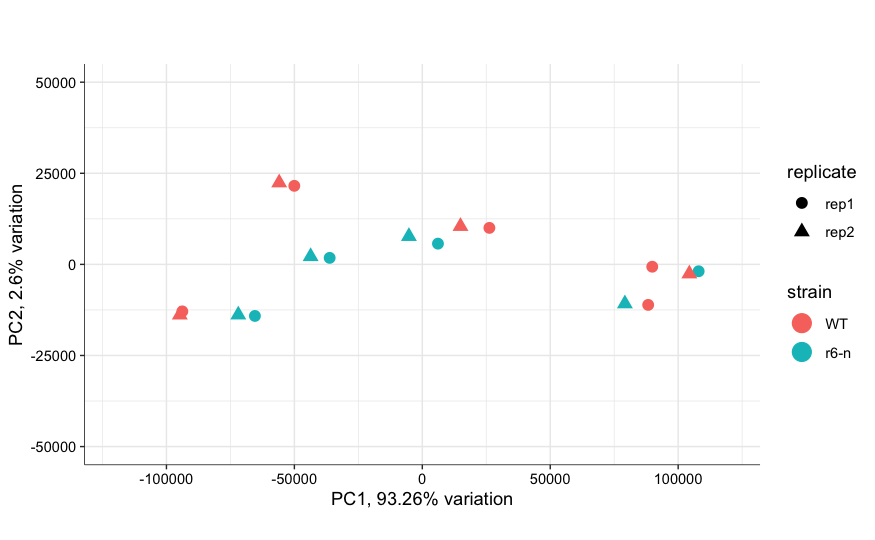

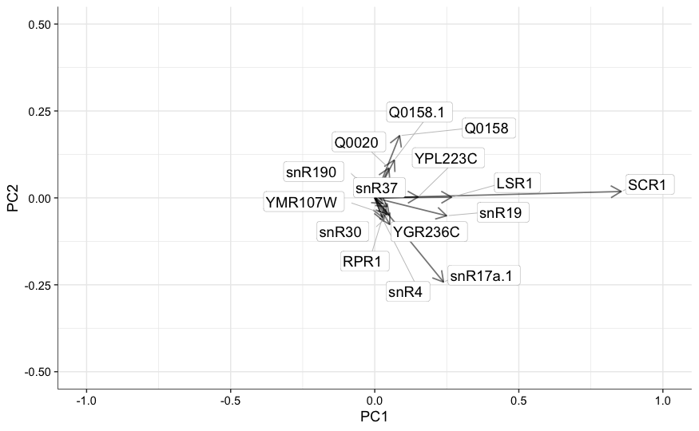

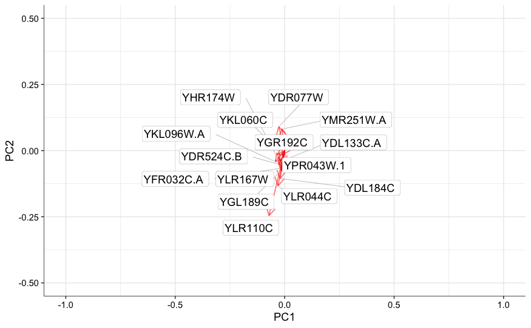

```r
images$PCAtools.PC1.v.PC2
images$KA.PC1.v.PC2$PC_x_pos

images$KA.PC1.v.PC2$PC_x_neg
```

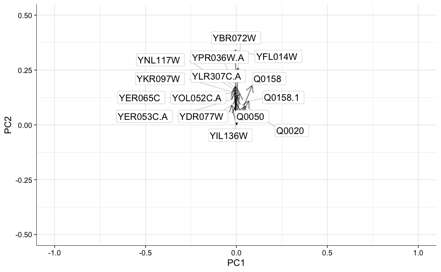

```r
images$KA.PC1.v.PC2$PC_y_pos
```

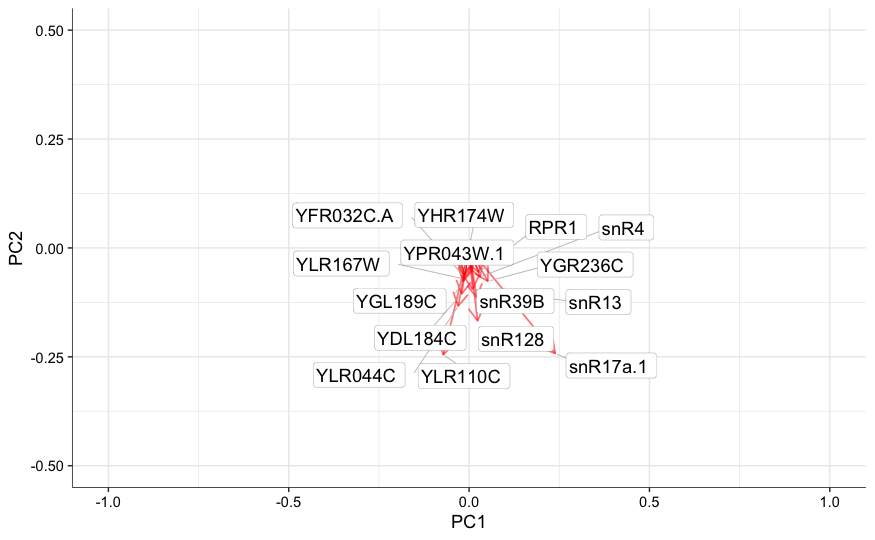

```r
images$KA.PC1.v.PC2$PC_y_neg
```